# Analiza Korespondencji

Adam Michalski

# Wstęp

W ramach tego projektu przeprowadzona zostanie analiza korespondencji dla danych dotyczących wyników ostatnich wyborów do sejmu w Polsce. Wprowadźmy najpierw pożadane dane do programu i zastąpmy ich braki sygnalizujące brak komisji wyborczych pewnych partii w okręgach wyborczych zerami:

```r
wyniki_wyborow_okregi <- read.csv("wyniki_gl_na_listy_po_okregach_sejm2023.csv", head = TRUE, sep = ";")
wyniki_2023_okr <- wyniki_wyborow_okregi[, c(27:38)]
wyniki_2023_okr[is.na(wyniki_2023_okr)] <- 0
colnames(wyniki_2023_okr) <- c("BS", "PSL", "Lew", "PIS", "Konf", "KO", "PJJ", "RDiP", "NK", "Ant", "RNP", "MN")
rownames(wyniki_2023_okr) <- 1:41
str(wyniki_2023_okr)
```

```
## 'data.frame':    41 obs. of  12 variables:
##  $ BS  : int  16748 5808 22412 8905 7758 10344 9522 11954 5624 8597 ...
##  $ PSL : int  53958 39215 106624 80426 84308 102894 59577 77933 54283 54479 ...
##  $ Lew : int  47715 25806 88089 52959 60473 37083 25691 47911 55770 25340 ...
##  $ PIS : int  174643 107797 206899 162603 183131 294847 231882 143530 122433 184929 ...
##  $ Konf: int  31770 19478 54132 34266 34232 54325 35594 33672 25428 30247 ...
##  $ KO  : int  169540 120188 286713 186914 158719 131712 79501 195091 187527 86083 ...
##  $ PJJ : num  7496 5068 11185 7846 6710 ...
##  $ RDiP: num  0 0 0 0 2266 ...
##  $ NK  : num  0 0 0 0 0 0 0 0 0 0 ...
##  $ Ant : num  0 0 0 0 0 ...
##  $ RNP : num  0 0 0 0 0 0 0 0 0 0 ...
##  $ MN  : num  0 0 0 0 0 0 0 0 0 0 ...
```

```r
dane <- as.matrix(wyniki_2023_okr)
str(dane)
```

```
##  num [1:41, 1:12] 16748 5808 22412 8905 7758 ...
##  - attr(*, "dimnames")=List of 2
##   ..$ : chr [1:41] "1" "2" "3" "4" ...
##   ..$ : chr [1:12] "BS" "PSL" "Lew" "PIS" ...
```

Analizować będziemy następujący problem: Czy istnieje i jaką ma postać zależność między okręgiem wyborczym/województwem, a poparciem dla poszczególnych partii politycznych w ostatnich wyborach do sejmu w Polsce. Pobrane dane są już w postaci tabeli kontygencji.

# Test niezależności danych

Skłonność do grupowania danych zilustrujemy w oparciu o mapy ciepła:

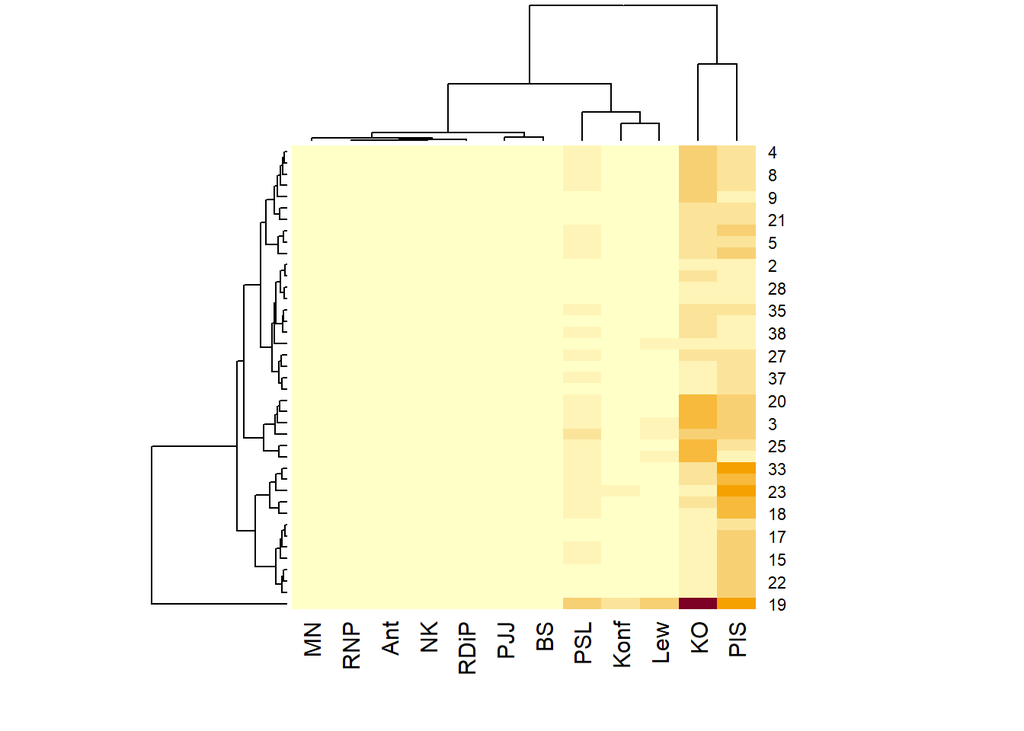

```r
heatmap(dane, scale = "none")
```

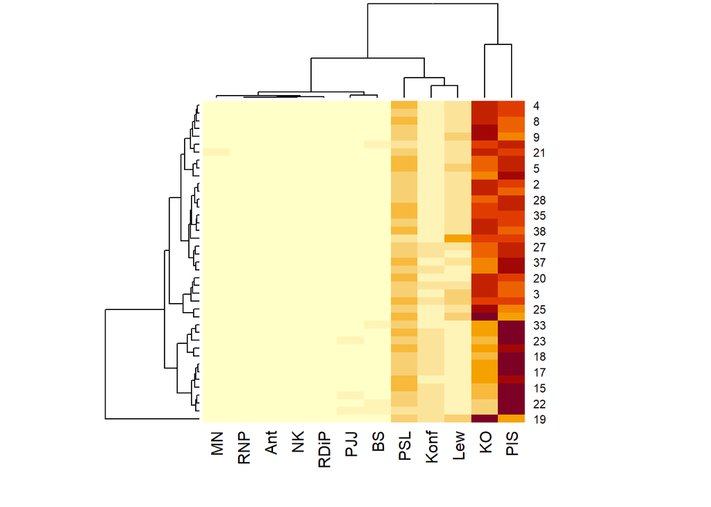

```r
heatmap(dane, scale="row")
```

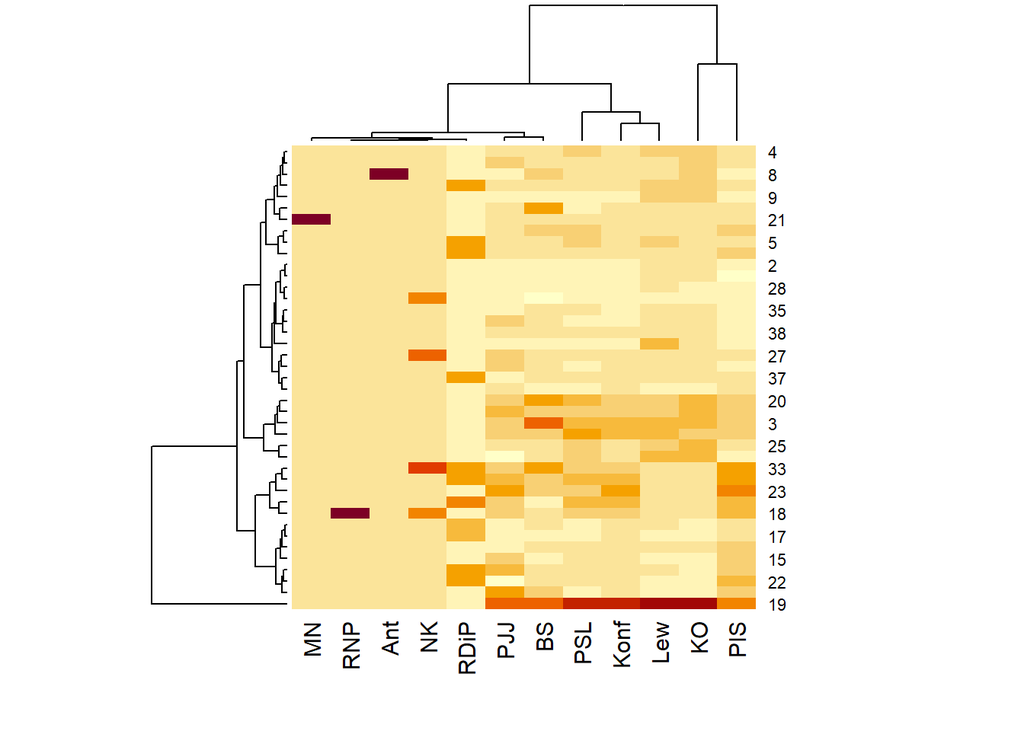

```r
heatmap(dane, scale="col")
```

Odpowiedź na pytanie o niezależność danych uzyskamy w oparciu o test $\chi^2$:

```r
test <- chisq.test(dane)
test
```

```
##
##  Pearson's Chi-squared test
##
## data:  dane
## X-squared = 2862632, df = 440, p-value < 2.2e-16
```

Skoro odrzuciliśmy hipotezę o niezależności w następnej kolejności spróbujemy ustalić postać zależności między okręgiem wyborczym a poszczególnymi partiami.

# Analiza korespondencji pełnych danych z podziałem na okręgi wyborcze

Na początek stworzymy tabelę korespondencji:

```r
n <- sum(dane)
P <- dane/n
str(P)
```

```
##  num [1:41, 1:12] 0.000775 0.000269 0.001038 0.000412 0.000359 ...
##  - attr(*, "dimnames")=List of 2
##   ..$ : chr [1:41] "1" "2" "3" "4" ...
##   ..$ : chr [1:12] "BS" "PSL" "Lew" "PIS" ...
```

Następnie obliczymy częstości brzegowe zwane w analizie korespondencji masami wierszy i kolumn:

```r
masa_w <- rowSums(P)
masa_w
```

```
##          1          2          3          4          5          6          7
## 0.02323830 0.01497268 0.03593396 0.02472228 0.02489258 0.03002069 0.02115474
##          8          9         10         11         12         13         14
## 0.02394077 0.02113992 0.01837408 0.02468565 0.01688552 0.03507586 0.01978508
##         15         16         17         18         19         20         21
## 0.01868765 0.02049237 0.01811399 0.02497644 0.07939736 0.03383595 0.02222416
##         22         23         24         25         26         27         28
## 0.02046593 0.03119814 0.02821008 0.02853620 0.03162056 0.02062105 0.01499958
##         29         30         31         32         33         34         35
## 0.01793832 0.01766929 0.02436333 0.01750080 0.03052007 0.01386232 0.01810733
##         36         37         38         39         40         41
## 0.02510882 0.01941239 0.01913420 0.02759860 0.01491660 0.02566636
```

```r
masa_k <- colSums(P)
masa_k
```

```
##           BS          PSL          Lew          PIS         Konf           KO
## 1.857017e-02 1.440347e-01 8.607890e-02 3.537977e-01 7.164825e-02 3.069640e-01
##          PJJ         RDiP           NK          Ant          RNP           MN
## 1.625709e-02 1.150640e-03 2.132736e-04 5.352676e-05 3.810772e-05 1.193610e-03
```

Wyznaczamy dalej teoretyczne częstości łączne, których oczekiwalibyśmy w przypadku całkowitej niezależności:

```r
teor <- outer(masa_w, masa_k, "*")
str(teor)
```

```
##  num [1:41, 1:12] 0.000432 0.000278 0.000667 0.000459 0.000462 ...
##  - attr(*, "dimnames")=List of 2
##   ..$ : chr [1:41] "1" "2" "3" "4" ...
##   ..$ : chr [1:12] "BS" "PSL" "Lew" "PIS" ...
```

Na koniec wyznaczymy standaryzowane reszty pearsonowskie niosące informacje o odchyłkach od niezależności danych:

```r
E <- (P-teor)/teor^(1/2)
str(E)
```

```
##  num [1:41, 1:12] 0.016557 -0.000547 0.014341 -0.002183 -0.004792 ...
##  - attr(*, "dimnames")=List of 2
##   ..$ : chr [1:41] "1" "2" "3" "4" ...
##   ..$ : chr [1:12] "BS" "PSL" "Lew" "PIS" ...
```

Zauważmy, że otrzymujemy poniżej ręcznie policzoną wartość będącą wynikiem testu niezależności $\chi^2$

```r
n*sum(E*E)
```

```
## [1] 2862632
```

```r
test
```

```
##
##  Pearson's Chi-squared test
##
## data:  dane
## X-squared = 2862632, df = 440, p-value < 2.2e-16
```

Mapy ciepła odchyłek od niezależności wyglądają następująco:

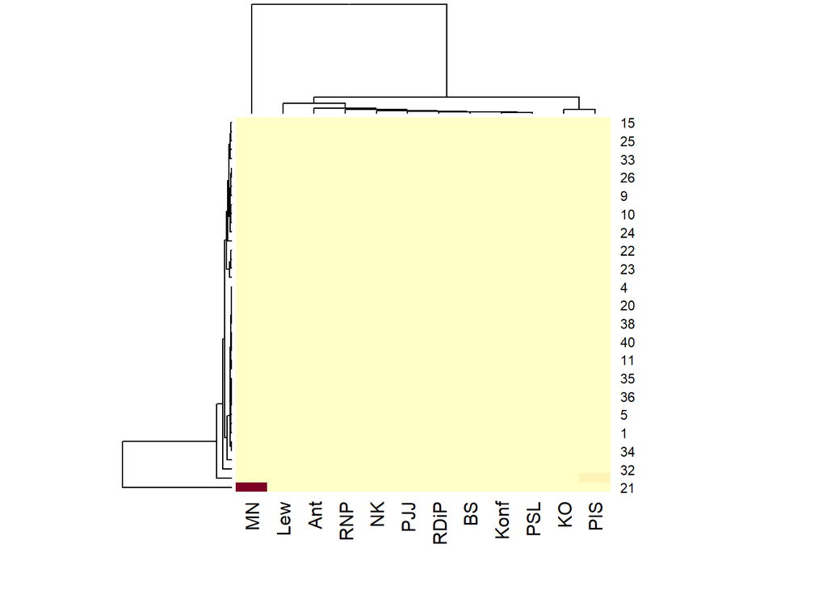

```r
heatmap(E*E, scale = "none")
```

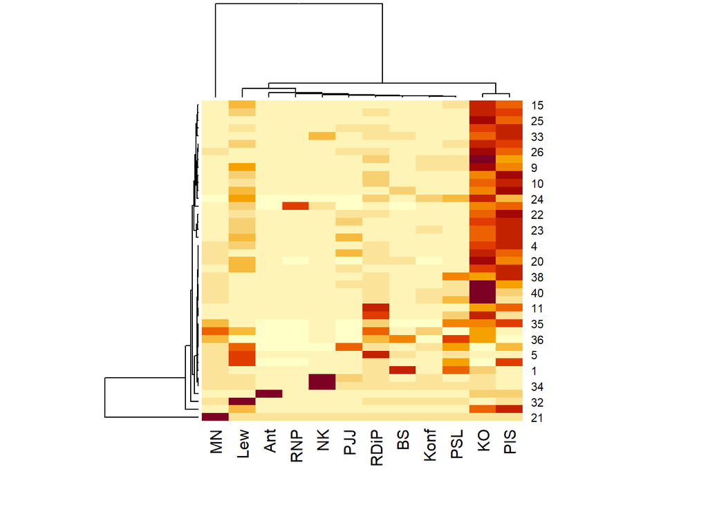

```r
heatmap(E*E, scale="row")
```

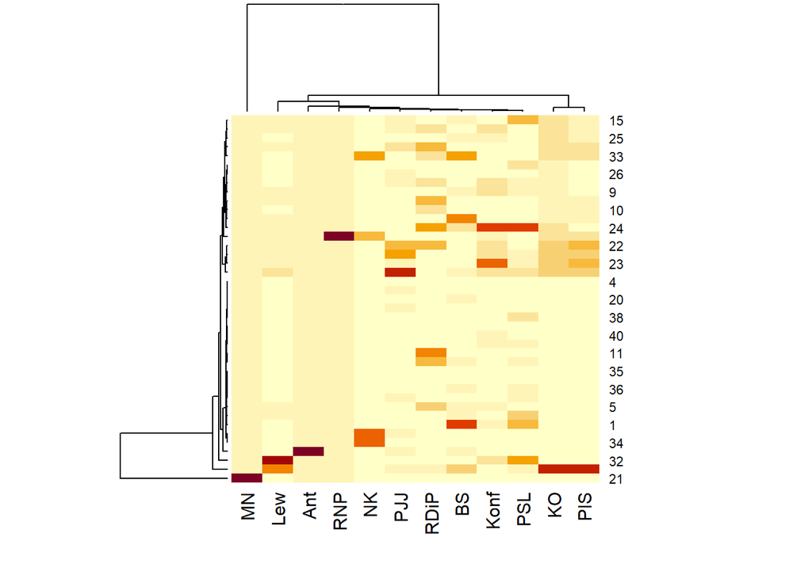

```r
heatmap(E*E, scale="col")
```

Na tym etapie pracy z danymi możemy zauważyć, że partie MN(Mniejszość Niemiecka) ANT(Antypartia) oraz RNP(Ruch Naprawy Polski) bardzo wyraźnie odstają od niezależności. Jest to spowodowane faktem, iż wszystkie ich głosy pochodzą z zaledwie jednogo z okręgów wyborczych, co daje jawną postać zależności danych.

# Metody wizualizacji wyników analizy

Trudno zaprezentować dane o odchyłkach od niezależności w innej formie wizualnej od map ciepła, gdyż mamy obecnie do czynienia z aż $41\times12$ wymiarami danych.

Aby jednak tego dokonać zastosujemy dekompozycję SVD badanej macierzy standaryzowanych reszt pearsonowskich $E$. Metoda ta stanowi uogólnienie diagonalizacji na macierze niekwadratowe takie, jak badana macierz $E$ wymiarów $41\times 12$. Dekompozycja ta polega na znajdowaniu wartości osobliwych, czyli dodatnich pierwiastków wartości własnych macierzy powstałej z pomnożenia macierzy $E$ przez jej transpozycję w dowolnej kolejności ( niezerowe wartości własne macierzy $E\cdot E^T$ i $E^T\cdot E$ okazują się być zawsze równe). Wektory osobliwe, czyli wektory własne pochodzące od poszczególnych wartości własnych macierzy $E\cdot E^T$ wyznaczają bazę przestrzeni operatorów liniowych najlepiej aproksymujących operator liniowy o macierzy $E$. Korzystając z tego faktu możemy ograniczając się do dwóch wektorów osobliwych pochodzących od dwóch najwięszkych wartości osobliwych sprowadzić badanie danych do tylko 2 wymiarów, które można przedstawić na wykresie zachowując jak najwięcej informacji o całych danych. Skorzystamy do tego celu z dostępnej w R funkcji svd:

```r
S <- svd(E)
str(S)
```

```
## List of 3
##  $ d: num [1:12] 0.2463 0.228 0.0712 0.0612 0.0529 ...
##  $ u: num [1:41, 1:12] 0.0303 0.0431 0.144 0.0717 0.0106 ...
##  $ v: num [1:12, 1:12] -0.0312 -0.0422 0.3325 -0.6373 -0.0959 ...
```

Korzystając z powyższej dekompozycji macierzy $E\cdot E^T$ standaryzując współrzędne wierszy i kolumn(poprzez dzielenie ich przez pierwiastki z odpowiednich częstości brzegowych) otrzymujemy następujący wykres zwany mapą percepcji:

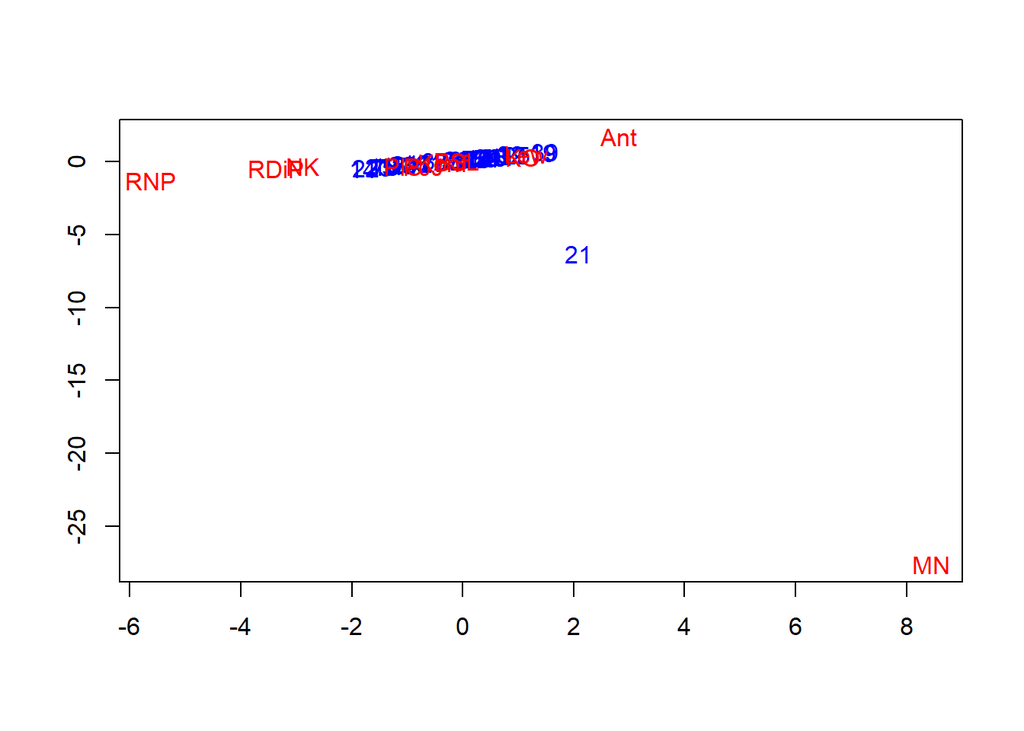

```r
X <- diag(1/sqrt(masa_w)) %*% S$u
Y <- diag(1/sqrt(masa_k)) %*% S$v
plot(rbind(X[,1:2], Y[,1:2]), col = "white", xlab = "", ylab = "", main = "")
text(X[,1:2], levels(wyniki_2023_okr$Nr.okręgu), col = "blue")
text(Y[,1:2], names(wyniki_2023_okr), col = "red")
```

Na podstawie wykresu jesteśmy w stanie odczytać iż partie MN(Mniejszość Niemiecka) RNP(Ruch naprawy Polski), ANT(Antypartia), NK(Normalny Kraj), RDiP(Ruch Dobrobytu i Pokoju) stanowczo odstają od pozostałych danych wraz z okręgiem 21(woj. Opolskie). Pozostałe dane są bardzo ściśle zgrupowane, co nie pozwala na wnioskowanie o zależności między nimi.

Do analizy korespondencji istnieje w R gotowa funkcja w pakiecie ca, za której pomocą możemy natychmiastowo otrzymać podobną mapę percepcji. W tym konkretnym przypadku okazuje się jednak, że ręczne stworzenie tego wykresu prowadzi do bardziej czytelnej reprezentacji tych odchyłek, gdyż widoczne są numery okręgów wyborczych oraz jest lepiej dobrana skala.

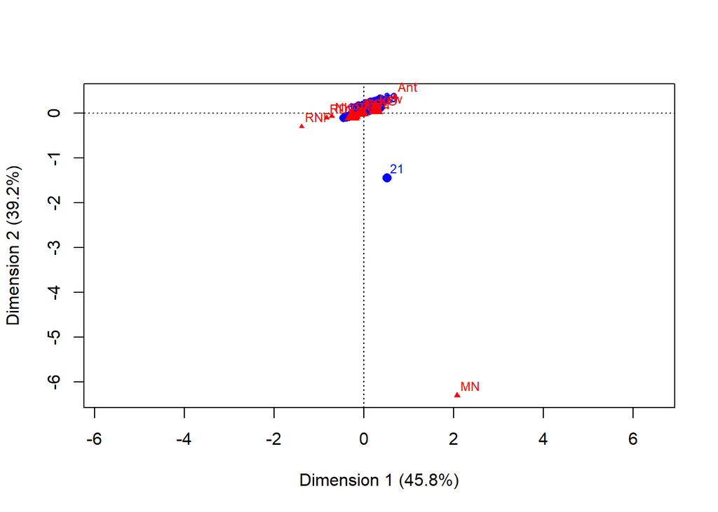

```r
library(ca)
plot(ca(dane), mass=T)
```

Oprócz rysowania wykresów oraz informowania o procentowym wkładzie wyświetlanych wymiarów w całość danych funkcja ta potrafi podać dodatkowe informacje dotyczącej analizy takowych danych.

```r
ca(dane)
```

```
##
##  Principal inertias (eigenvalues):
##            1       2        3        4        5        6       7
## Value      0.06067 0.051998 0.005071 0.003741 0.002801 0.00243 0.002159
## Percentage 45.77%  39.23%   3.83%    2.82%    2.11%    1.83%   1.63%
##            8        9        10       11
## Value      0.001235 0.001118 0.000814 0.000513
## Percentage 0.93%    0.84%    0.61%    0.39%
##
##
##  Rows:
##                1        2        3        4        5         6         7
## Mass    0.023238 0.014973 0.035934 0.024722 0.024893  0.030021  0.021155
## ChiDist 0.170064 0.152930 0.227788 0.137775 0.150069  0.294078  0.398254
## Inertia 0.000672 0.000350 0.001865 0.000469 0.000561  0.002596  0.003355
## Dim. 1  0.198855 0.351966 0.759890 0.456267 0.067291 -1.140478 -1.518909
## Dim. 2  0.217543 0.249309 0.415648 0.307638 0.209952 -0.214907 -0.340260
##                8        9        10        11        12       13        14
## Mass    0.023941 0.021140  0.018374  0.024686  0.016886 0.035076  0.019785
## ChiDist 0.358046 0.291084  0.281261  0.187887  0.206958 0.145504  0.502772
## Inertia 0.003069 0.001791  0.001454  0.000871  0.000723 0.000743  0.005001
## Dim. 1  0.691497 1.025874 -1.067266 -0.598898 -0.779495 0.284055 -1.802026
## Dim. 2  0.387958 0.493037 -0.185369 -0.027875 -0.110245 0.270553 -0.467890
##                15        16        17        18       19       20        21
## Mass     0.018688  0.020492  0.018114  0.024976 0.079397 0.033836  0.022224
## ChiDist  0.394452  0.240417  0.328918  0.435882 0.386676 0.130954  1.524683
## Inertia  0.002908  0.001184  0.001960  0.004745 0.011871 0.000580  0.051664
## Dim. 1  -1.461061 -0.860329 -1.245285 -1.385127 1.433042 0.260577  2.080103
## Dim. 2  -0.329892 -0.121568 -0.250077 -0.297835 0.636201 0.224880 -6.297425
##                22        23        24       25       26        27        28
## Mass     0.020466  0.031198  0.028210 0.028536 0.031621  0.020621  0.015000
## ChiDist  0.481134  0.403406  0.317501 0.273737 0.180181  0.202998  0.073800
## Inertia  0.004738  0.005077  0.002844 0.002138 0.001027  0.000850  0.000082
## Dim. 1  -1.750849 -1.516390 -1.052624 0.967000 0.541720 -0.273903 -0.095457
## Dim. 2  -0.403759 -0.355766 -0.179857 0.460029 0.313816  0.064776  0.131739
##               29        30       31       32        33        34       35
## Mass    0.017938  0.017669 0.024363 0.017501  0.030520  0.013862 0.018107
## ChiDist 0.156472  0.128965 0.152042 0.475990  0.319150  0.224635 0.098655
## Inertia 0.000439  0.000294 0.000563 0.003965  0.003109  0.000700 0.000176
## Dim. 1  0.455153 -0.280680 0.434362 0.856498 -1.105923 -0.001172 0.189682
## Dim. 2  0.293100  0.044847 0.280644 0.515661 -0.189272  0.159673 0.214182
##                36        37       38       39       40       41
## Mass     0.025109  0.019412 0.019134 0.027599 0.014917 0.025666
## ChiDist  0.089100  0.197054 0.166548 0.411828 0.184415 0.237208
## Inertia  0.000199  0.000754 0.000531 0.004681 0.000507 0.001444
## Dim. 1  -0.147134 -0.495972 0.384728 1.482795 0.549039 0.704471
## Dim. 2   0.115133  0.028564 0.275355 0.657095 0.318493 0.382268
##
##
##  Columns:
##                BS       PSL      Lew       PIS      Konf       KO       PJJ
## Mass     0.018570  0.144035 0.086079  0.353798  0.071648 0.306964  0.016257
## ChiDist  0.263807  0.133672 0.368060  0.274658  0.135393 0.282964  0.404090
## Inertia  0.001292  0.002574 0.011661  0.026689  0.001313 0.024578  0.002655
## Dim. 1  -0.229029 -0.111095 1.133377 -1.071386 -0.358446 1.085672 -0.698256
## Dim. 2   0.025905  0.042106 0.528238 -0.300919 -0.063516 0.317795 -0.309836
##              RDiP        NK      Ant       RNP         MN
## Mass     0.001151  0.000213 0.000054  0.000038   0.001194
## ChiDist  1.703687  3.257568 6.385120  6.248018   6.632953
## Inertia  0.003340  0.002263 0.002182  0.001488   0.052514
## Dim. 1  -3.372765 -2.885610 2.807400 -5.623460   8.444989
## Dim. 2  -0.457473 -0.313269 1.701346 -1.306121 -27.616674
```

W wynikach pojawia się pojęcie inercji rozumianej jako iloraz wyniku testu $\chi^2$ danych oraz ilości wszystkich obserwacji(w naszym przypadku jest to ilość wszystkich osób o ważnych głosach). Możemy również rozważać inercję dla poszczególnych partii otrzymując bardziej szczegółową informację o udziale poszczególnych wierszy lub kolumn w wyniku testu $\chi^2$.

```r
sum(ca(dane)$rowinertia)
```

```
## [1] 0.1325497
```

```r
x <- ca(dane)$rowinertia/sum(ca(dane)$rowinertia)
x
```

```
##  [1] 0.0050705193 0.0026418432 0.0140666192 0.0035403717 0.0042293510
##  [6] 0.0195869663 0.0253133535 0.0231546138 0.0135132790 0.0109659234
## [11] 0.0065744817 0.0054563400 0.0056024967 0.0377313097 0.0219363234
## [16] 0.0089360370 0.0147846032 0.0358005577 0.0895614833 0.0043776284
## [21] 0.3897678929 0.0357424763 0.0383031166 0.0214543802 0.0161318051
## [26] 0.0077447449 0.0064108729 0.0006163307 0.0033134233 0.0022170920
## [31] 0.0042489638 0.0299140818 0.0234529716 0.0052773030 0.0013295750
## [36] 0.0015038319 0.0056868510 0.0040041321 0.0353134050 0.0038272304
## [41] 0.0108954180
```

```r
ca(dane)$rowinertia
```

```
##  [1] 6.720957e-04 3.501755e-04 1.864526e-03 4.692751e-04 5.605991e-04
##  [6] 2.596246e-03 3.355277e-03 3.069137e-03 1.791181e-03 1.453530e-03
## [11] 8.714454e-04 7.232361e-04 7.426091e-04 5.001273e-03 2.907653e-03
## [16] 1.184469e-03 1.959694e-03 4.745352e-03 1.187135e-02 5.802532e-04
## [21] 5.166361e-02 4.737654e-03 5.077066e-03 2.843771e-03 2.138266e-03
## [26] 1.026563e-03 8.497591e-04 8.169443e-05 4.391932e-04 2.938748e-04
## [31] 5.631988e-04 3.965102e-03 3.108684e-03 6.995048e-04 1.762347e-04
## [36] 1.993324e-04 7.537903e-04 5.307464e-04 4.680780e-03 5.072981e-04
## [41] 1.444184e-03
```

Spróbujemy w następnej kolejności przedstawić wykres najważniejszych 3 wymiarów całych danych(tych o największej wariancji):

```r
library(rgl)
plot3d(ca(dane))
rglwidget()
```

[interactive chart not shown]

# Analiza korespondencji danych bez najrzadziej wybieranych partii z podziałem na okręgi wyborcze

W dalszej części analizy korespondencji rozważamy dane bez partii MN(Mniejszość Niemiecka), RNP(Ruch Naprawy Polski), ANT(Antypartia), NK(Normalny Kraj) oraz RDiP(Ruch Dobrobytu i Pokoju), gdyż odstają od pozostałych danych, czyli już dla nich zdołaliśmy ustalić postaci zależności względem okręgu(pojawiają się tylko w kilku okręgach).

```r
wyniki_2023_okr2 <- wyniki_2023_okr[, 1:7]
str(wyniki_2023_okr2)
```

```
## 'data.frame':    41 obs. of  7 variables:
##  $ BS  : int  16748 5808 22412 8905 7758 10344 9522 11954 5624 8597 ...
##  $ PSL : int  53958 39215 106624 80426 84308 102894 59577 77933 54283 54479 ...
##  $ Lew : int  47715 25806 88089 52959 60473 37083 25691 47911 55770 25340 ...
##  $ PIS : int  174643 107797 206899 162603 183131 294847 231882 143530 122433 184929 ...
##  $ Konf: int  31770 19478 54132 34266 34232 54325 35594 33672 25428 30247 ...
##  $ KO  : int  169540 120188 286713 186914 158719 131712 79501 195091 187527 86083 ...
##  $ PJJ : num  7496 5068 11185 7846 6710 ...
```

```r
dane2 <- dane[, 1:7]
str(dane2)
```

```
##  num [1:41, 1:7] 16748 5808 22412 8905 7758 ...
##  - attr(*, "dimnames")=List of 2
##   ..$ : chr [1:41] "1" "2" "3" "4" ...
##   ..$ : chr [1:7] "BS" "PSL" "Lew" "PIS" ...
```

Mapy ciepła tych danych są postaci:

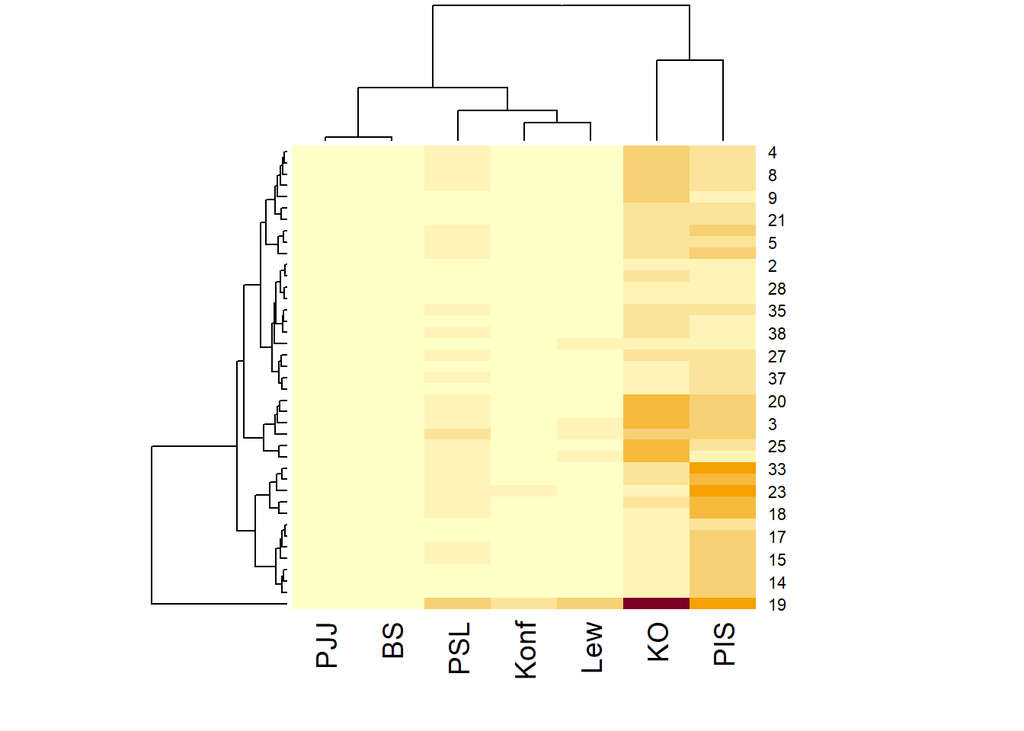

```r
heatmap(dane2, scale = "none")
```

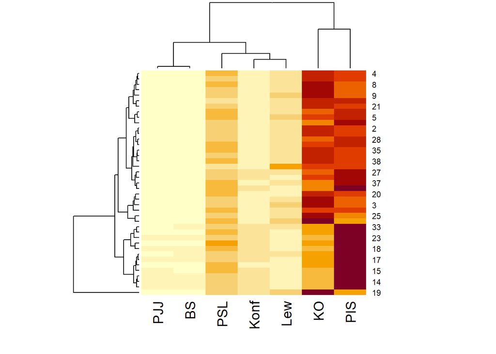

```r
heatmap(dane2, scale="row")
```

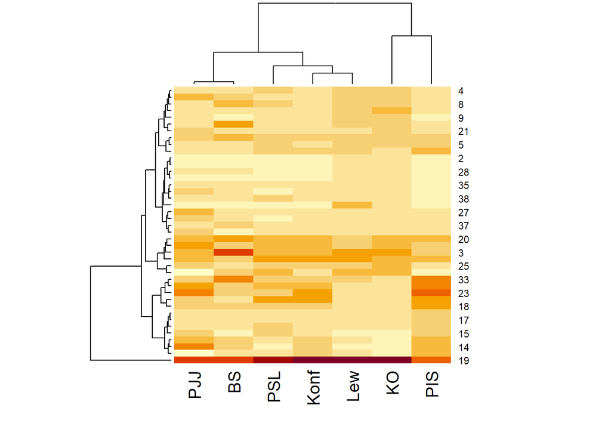

```r
heatmap(dane2, scale="col")
```

Wynikiem testu $\chi^2$ jest liczba:

```r
test2 <- chisq.test(dane2)
test2
```

```
##
##  Pearson's Chi-squared test
##
## data:  dane2
## X-squared = 1525436, df = 240, p-value < 2.2e-16
```

Odrzucamy hipotezę o niezależności, więc ponownie możemy przeprowadzić analizę korespondencji w celu szukania postaci tej zależności.

```r
n2 <- sum(dane2)
P2 <- dane2/n2
str(P2)
```

```
##  num [1:41, 1:7] 0.000778 0.00027 0.001041 0.000413 0.00036 ...
##  - attr(*, "dimnames")=List of 2
##   ..$ : chr [1:41] "1" "2" "3" "4" ...
##   ..$ : chr [1:7] "BS" "PSL" "Lew" "PIS" ...
```

```r
masa_w <- rowSums(P2)
masa_w
```

```
##          1          2          3          4          5          6          7
## 0.02330003 0.01501245 0.03602941 0.02478795 0.02485350 0.02999597 0.02110995
##          8          9         10         11         12         13         14
## 0.02395069 0.02119607 0.01834456 0.02462239 0.01693037 0.03516903 0.01983764
##         15         16         17         18         19         20         21
## 0.01873728 0.02054680 0.01807074 0.02495610 0.07960826 0.03392583 0.02108641
##         22         23         24         25         26         27         28
## 0.02041727 0.03128101 0.02815070 0.02861200 0.03170455 0.02061816 0.01503942
##         29         30         31         32         33         34         35
## 0.01798597 0.01771623 0.02442805 0.01754728 0.03043150 0.01385383 0.01815542
##         36         37         38         39         40         41
## 0.02517551 0.01936483 0.01918502 0.02767191 0.01495622 0.02563370
```

```r
masa_k <- colSums(P2)
masa_k
```

```
##         BS        PSL        Lew        PIS       Konf         KO        PJJ
## 0.01861950 0.14441726 0.08630755 0.35473747 0.07183857 0.30777938 0.01630027
```

```r
teor2 <- outer(masa_w, masa_k, "*")
str(teor2)
```

```
##  num [1:41, 1:7] 0.000434 0.00028 0.000671 0.000462 0.000463 ...
##  - attr(*, "dimnames")=List of 2
##   ..$ : chr [1:41] "1" "2" "3" "4" ...
##   ..$ : chr [1:7] "BS" "PSL" "Lew" "PIS" ...
```

```r
E2 <- (P2-teor2)/teor2^(1/2)
str(E2)
```

```
##  num [1:41, 1:7] 0.016502 -0.000591 0.014272 -0.002239 -0.004769 ...
##  - attr(*, "dimnames")=List of 2
##   ..$ : chr [1:41] "1" "2" "3" "4" ...
##   ..$ : chr [1:7] "BS" "PSL" "Lew" "PIS" ...
```

Mapy ciepła odchyłek od niezależności wyglądają następująco:

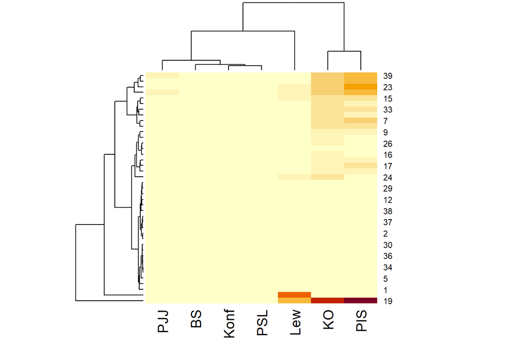

```r
heatmap(E2*E2, scale = "none")
```

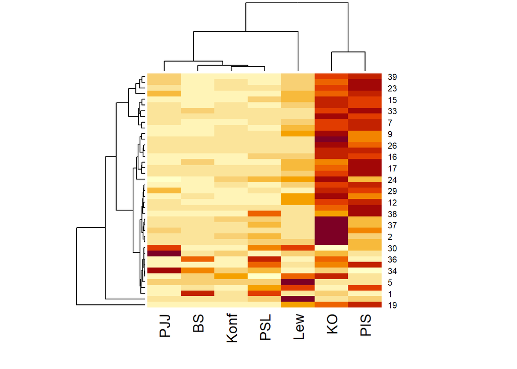

```r
heatmap(E2*E2, scale="row")
```

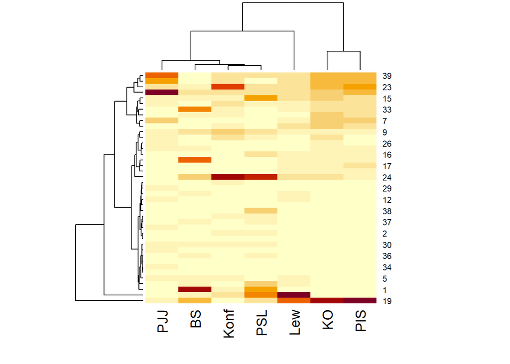

```r
heatmap(E2*E2, scale="col")
```

```r
S <- svd(E2)
str(S)
```

```
## List of 3
##  $ d: num [1:7] 0.243 0.0702 0.0568 0.0447 0.0329 ...
##  $ u: num [1:41, 1:7] 0.0359 0.0483 0.1589 0.0805 0.0259 ...
##  $ v: num [1:7, 1:7] -0.0305 -0.0379 0.3643 -0.6695 -0.0993 ...
```

Korzystając z powyższej dekompozycji macierzy $E2\cdot E2^T$ standaryzując współrzędne wierszy i kolumn dostajemy następujący wykres:

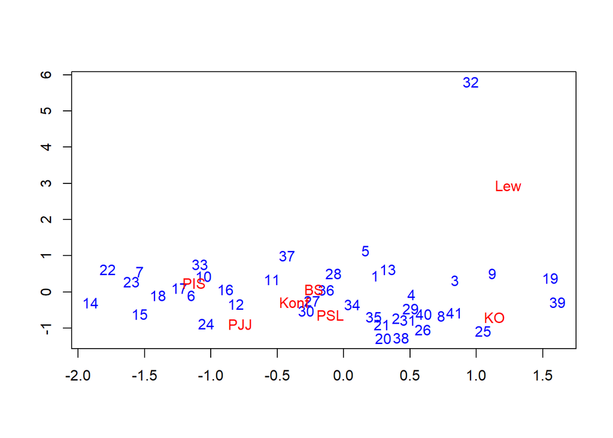

```r
X <- diag(1/sqrt(masa_w)) %*% S$u
Y <- diag(1/sqrt(masa_k)) %*% S$v
plot(rbind(X[,1:2], Y[,1:2]), col = "white", xlab = "", ylab = "", main = "")
text(X[,1:2], levels(wyniki_2023_okr2$Nr.okręgu), col = "blue")
text(Y[,1:2], names(wyniki_2023_okr2), col = "red")
```

Wykres w 3D wygląda następująco:

```r
library(rgl)
plot3d(ca(dane2))
rglwidget()
```

[interactive chart not shown]

Na podstawie powyższych wykresów jesteśmy w stanie odczytać, iż 32 okrąg wyborczy (w tym okręgu znajdują się powiaty będziński oraz zawierciański wraz z miastami Dąbrowa Górnicza Jaworzno i Sosnowiec) wykazuje szczególne poparcie dla Lewicy, okręgi 19 (Warszawa) i 39 (Poznań) wykazują poparcie przede wszystkim dla Koalicji Obywatelskiej.

# Analiza korespondencji danych bez najrzadziej wybieranych partii i odstającego okręgu z podziałem na okręgi wyborcze

W następnej kolejności rozważać będziemy dane bez odstających partii oraz bez okręgu 32 leżącego w województwie śląskim, które na podstawie dotychczasowej analizy znacząco wyróżnia się poparciem dla Lewicy.

```r
wyniki_2023_okr3 <- wyniki_2023_okr2[-c(32), ]
str(wyniki_2023_okr3)
```

```
## 'data.frame':    40 obs. of  7 variables:
##  $ BS  : int  16748 5808 22412 8905 7758 10344 9522 11954 5624 8597 ...
##  $ PSL : int  53958 39215 106624 80426 84308 102894 59577 77933 54283 54479 ...
##  $ Lew : int  47715 25806 88089 52959 60473 37083 25691 47911 55770 25340 ...
##  $ PIS : int  174643 107797 206899 162603 183131 294847 231882 143530 122433 184929 ...
##  $ Konf: int  31770 19478 54132 34266 34232 54325 35594 33672 25428 30247 ...
##  $ KO  : int  169540 120188 286713 186914 158719 131712 79501 195091 187527 86083 ...
##  $ PJJ : num  7496 5068 11185 7846 6710 ...
```

```r
dane3 <- dane2[-c(32), ]
str(dane3)
```

```
##  num [1:40, 1:7] 16748 5808 22412 8905 7758 ...
##  - attr(*, "dimnames")=List of 2
##   ..$ : chr [1:40] "1" "2" "3" "4" ...
##   ..$ : chr [1:7] "BS" "PSL" "Lew" "PIS" ...
```

Mapy ciepła tych danych są postaci:

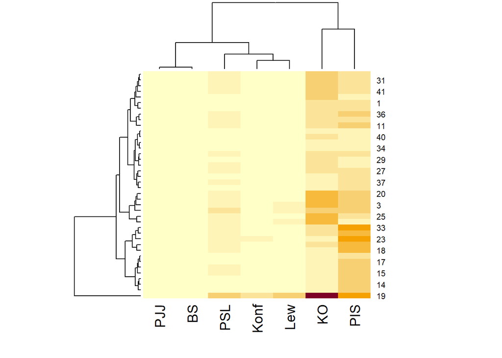

```r
heatmap(dane3, scale = "none")
```

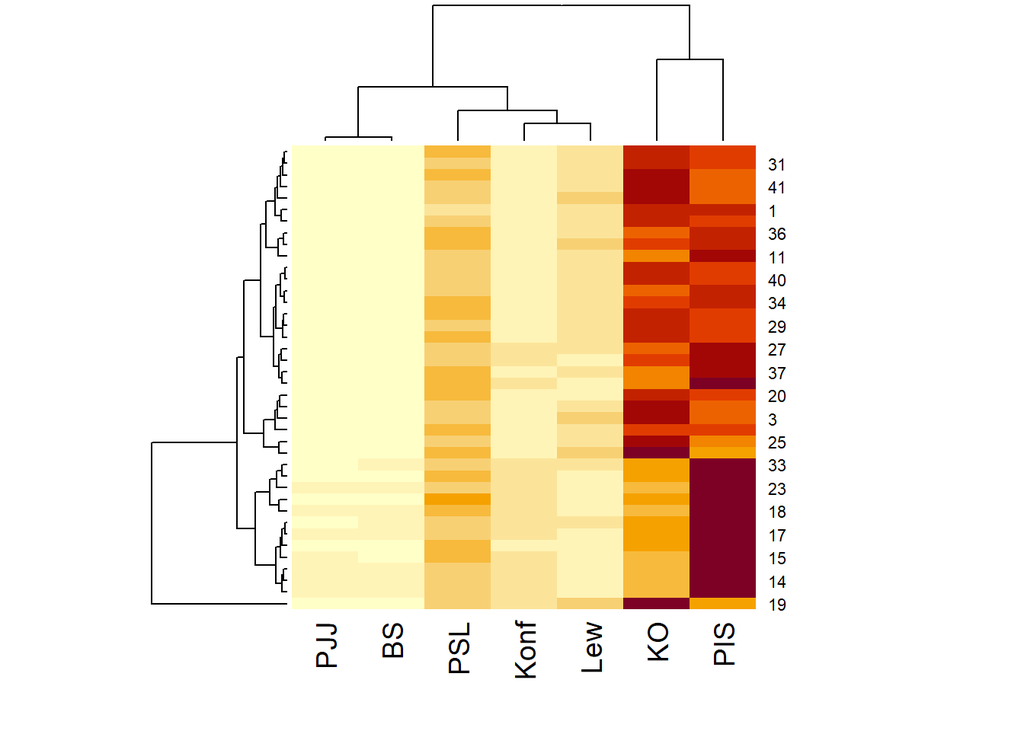

```r
heatmap(dane3, scale="row")
```

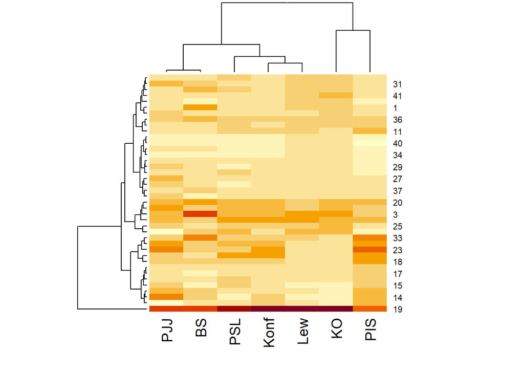

```r
heatmap(dane3, scale="col")
```

Wynikiem testu $\chi^2$ jest liczba:

```r
test3 <- chisq.test(dane3)
test3
```

```
##
##  Pearson's Chi-squared test
##
## data:  dane3
## X-squared = 1441893, df = 234, p-value < 2.2e-16
```

Odrzucamy hipotezę o niezależności, więc ponownie możemy przeprowadzić analizę korespondencji w celu szukania postaci tej zależności.

```r
n3 <- sum(dane3)
P3 <- dane3/n3
str(P3)
```

```
##  num [1:40, 1:7] 0.000791 0.000274 0.001059 0.000421 0.000367 ...
##  - attr(*, "dimnames")=List of 2
##   ..$ : chr [1:40] "1" "2" "3" "4" ...
##   ..$ : chr [1:7] "BS" "PSL" "Lew" "PIS" ...
```

```r
masa_w <- rowSums(P3)
masa_w
```

```
##          1          2          3          4          5          6          7
## 0.02371618 0.01528058 0.03667292 0.02523068 0.02529740 0.03053172 0.02148699
##          8          9         10         11         12         13         14
## 0.02437847 0.02157465 0.01867221 0.02506216 0.01723276 0.03579718 0.02019195
##         15         16         17         18         19         20         21
## 0.01907194 0.02091378 0.01839350 0.02540184 0.08103012 0.03453176 0.02146303
##         22         23         24         25         26         27         28
## 0.02078194 0.03183971 0.02865350 0.02912303 0.03227082 0.02098641 0.01530803
##         29         30         31         33         34         35         36
## 0.01830721 0.01803265 0.02486435 0.03097502 0.01410127 0.01847969 0.02562517
##         37         38         39         40         41
## 0.01971070 0.01952768 0.02816615 0.01522335 0.02609153
```

```r
masa_k <- colSums(P3)
masa_k
```

```
##         BS        PSL        Lew        PIS       Konf         KO        PJJ
## 0.01869220 0.14523775 0.08399082 0.35576232 0.07210509 0.30786487 0.01634695
```

```r
teor3 <- outer(masa_w, masa_k, "*")
str(teor3)
```

```
##  num [1:40, 1:7] 0.000443 0.000286 0.000685 0.000472 0.000473 ...
##  - attr(*, "dimnames")=List of 2
##   ..$ : chr [1:40] "1" "2" "3" "4" ...
##   ..$ : chr [1:7] "BS" "PSL" "Lew" "PIS" ...
```